# Global Warming Challenge

## Domanda di ricerca

In questa data challenge l’obiettivo è indagare se i mesi più freddi della norma 1951–1980 stiano scomparendo. Il contenuto di fondo è lo stesso dell’analisi sul riscaldamento globale, ciò che cambia è l’obiettivo di questa opera di data art, che fa leva sul sentimento dell’assenza, in questo caso l’assenza del freddo.

```r
library(tidyverse)
temp_raw <- read_csv(
  "data/gistemp.csv",
  skip = 1,
  na = c("***", "****"),
  show_col_types = FALSE
)

glimpse(temp_raw)
```

```
## Rows: 147
## Columns: 19
## $ Year  <dbl> 1880, 1881, 1882, 1883, 1884, 1885, 1886, 1887, 1888, 1889, 1890…
## $ Jan   <dbl> -0.19, -0.20, 0.16, -0.29, -0.13, -0.58, -0.44, -0.72, -0.34, -0…
## $ Feb   <dbl> -0.25, -0.14, 0.13, -0.37, -0.08, -0.34, -0.51, -0.57, -0.36, 0.…
## $ Mar   <dbl> -0.09, 0.03, 0.04, -0.12, -0.36, -0.27, -0.43, -0.35, -0.42, 0.0…
## $ Apr   <dbl> -0.16, 0.05, -0.16, -0.18, -0.40, -0.42, -0.28, -0.35, -0.21, 0.…
## $ May   <dbl> -0.10, 0.06, -0.14, -0.18, -0.33, -0.45, -0.24, -0.30, -0.22, -0…
## $ Jun   <dbl> -0.21, -0.19, -0.22, -0.07, -0.35, -0.44, -0.35, -0.25, -0.17, -…
## $ Jul   <dbl> -0.19, 0.00, -0.16, -0.08, -0.30, -0.34, -0.18, -0.26, -0.11, -0…
## $ Aug   <dbl> -0.10, -0.03, -0.08, -0.14, -0.28, -0.31, -0.30, -0.35, -0.16, -…
## $ Sep   <dbl> -0.15, -0.15, -0.15, -0.22, -0.27, -0.28, -0.23, -0.25, -0.12, -…
## $ Oct   <dbl> -0.23, -0.22, -0.23, -0.11, -0.25, -0.23, -0.27, -0.35, 0.01, -0…
## $ Nov   <dbl> -0.22, -0.19, -0.17, -0.24, -0.33, -0.24, -0.28, -0.26, 0.02, -0…
## $ Dec   <dbl> -0.18, -0.07, -0.36, -0.11, -0.31, -0.10, -0.25, -0.33, -0.04, -…
## $ `J-D` <dbl> -0.17, -0.09, -0.11, -0.18, -0.28, -0.33, -0.31, -0.36, -0.18, -…
## $ `D-N` <dbl> NA, -0.10, -0.09, -0.20, -0.27, -0.35, -0.30, -0.35, -0.20, -0.0…
## $ DJF   <dbl> NA, -0.17, 0.07, -0.34, -0.11, -0.41, -0.35, -0.51, -0.35, 0.01,…
## $ MAM   <dbl> -0.12, 0.05, -0.09, -0.16, -0.36, -0.38, -0.32, -0.33, -0.28, 0.…
## $ JJA   <dbl> -0.17, -0.07, -0.16, -0.10, -0.31, -0.36, -0.28, -0.29, -0.14, -…
## $ SON   <dbl> -0.20, -0.18, -0.18, -0.19, -0.28, -0.25, -0.26, -0.29, -0.03, -…
```

```r
temp <- temp_raw |>
  select(Year, Jan:Dec) |>
  pivot_longer(
    cols = Jan:Dec,
    names_to = "month",
    values_to = "anomaly"
  ) |>
  mutate(
    month = factor(month, levels = month.abb),
    date = as.Date(
      paste(Year, month, "01", sep = "-"),
      format = "%Y-%b-%d"
    )
  ) |>
  drop_na(anomaly) |>
  filter(Year <= 2025)

head(temp, n = 12)
```

```
## # A tibble: 12 × 4
##     Year month anomaly date
##    <dbl> <fct>   <dbl> <date>
##  1  1880 Jan     -0.19 1880-01-01
##  2  1880 Feb     -0.25 1880-02-01
##  3  1880 Mar     -0.09 1880-03-01
##  4  1880 Apr     -0.16 1880-04-01
##  5  1880 May     -0.1  1880-05-01
##  6  1880 Jun     -0.21 1880-06-01
##  7  1880 Jul     -0.19 1880-07-01
##  8  1880 Aug     -0.1  1880-08-01
##  9  1880 Sep     -0.15 1880-09-01
## 10  1880 Oct     -0.23 1880-10-01
## 11  1880 Nov     -0.22 1880-11-01
## 12  1880 Dec     -0.18 1880-12-01
```

Sintesi statistica di tutte le anomalie mensili dal 1880 al 2025.

```r
temp |>
  summarise(
    observations = n(),
    mean_anomaly = mean(anomaly),
    median_anomaly = median(anomaly),
    sd_anomaly = sd(anomaly),
    min_anomaly = min(anomaly),
    max_anomaly = max(anomaly)
  )
```

```
## # A tibble: 1 × 6
##   observations mean_anomaly median_anomaly sd_anomaly min_anomaly max_anomaly
##          <int>        <dbl>          <dbl>      <dbl>       <dbl>       <dbl>
## 1         1752       0.0833          -0.03      0.413       -0.81        1.48
```

Per ogni decennio calcolo l’anomalia media, il mese più freddo e la quota di mesi sotto la norma.

```r
decades <- temp |>
  mutate(decade = (Year %/% 10) * 10) |>
  group_by(decade) |>
  summarise(
    mean_anomaly = mean(anomaly),
    min_anomaly = min(anomaly),
    cold_share = mean(anomaly < 0),
    .groups = "drop"
  )

decades
```

```
## # A tibble: 15 × 4
##    decade mean_anomaly min_anomaly cold_share
##     <dbl>        <dbl>       <dbl>      <dbl>
##  1   1880      -0.212        -0.72    0.9
##  2   1890      -0.237        -0.81    0.983
##  3   1900      -0.313        -0.73    0.975
##  4   1910      -0.327        -0.81    0.983
##  5   1920      -0.236        -0.58    0.95
##  6   1930      -0.122        -0.44    0.833
##  7   1940       0.0433       -0.31    0.375
##  8   1950      -0.0478       -0.42    0.567
##  9   1960      -0.0303       -0.35    0.567
## 10   1970       0.0345       -0.27    0.433
## 11   1980       0.247        -0.04    0.0167
## 12   1990       0.386        -0.01    0.00833
## 13   2000       0.589         0.25    0
## 14   2010       0.804         0.45    0
## 15   2020       1.06          0.64    0
```

Per ogni anno si contano quanti mesi hanno anomalia negativa.

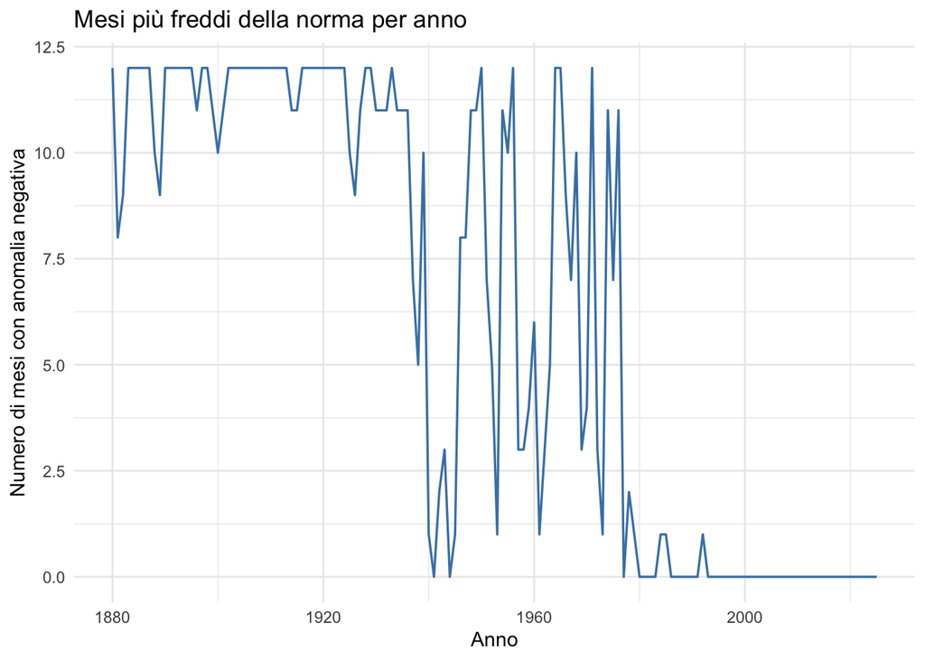

```r
cold_months <- temp |>
  group_by(Year) |>
  summarise(cold_months = sum(anomaly < 0), .groups = "drop")

ggplot(cold_months, aes(x = Year, y = cold_months)) +
  geom_line(color = "steelblue", linewidth = 0.6) +
  labs(
    title = "Mesi più freddi della norma per anno",
    x = "Anno",
    y = "Numero di mesi con anomalia negativa"
  ) +
  theme_minimal()
```

Calcolo la distribuzione delle anomalie decennio per decennio.

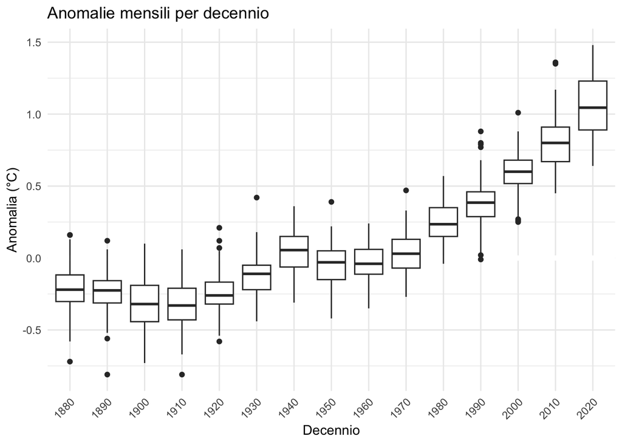

```r
library(modelr)

temp |>
  mutate(decade = (Year %/% 10) * 10) |>
  ggplot(aes(x = factor(decade), y = anomaly)) +
  geom_ref_line(h = 0) +
  geom_boxplot(show.legend = FALSE) +
  labs(
    title = "Anomalie mensili per decennio",
    x = "Decennio",
    y = "Anomalia (°C)"
  ) +
  theme_minimal() +
  theme(
    axis.text.x = element_text(angle = 45, hjust = 1)
  )
```

Cerchiamo l’ultimo mese sotto zero e l’ultimo sotto −0,1 °C, poi contiamo i mesi trascorsi dopo il primo, verificando che nessuno sia negativo.

```r
temp |>
  filter(anomaly < 0) |>
  arrange(desc(Year), desc(month)) |>
  head(1)
```

```
## # A tibble: 1 × 4
##    Year month anomaly date
##   <dbl> <fct>   <dbl> <date>
## 1  1992 Sep     -0.01 1992-09-01
```

```r
temp |>
  filter(anomaly <= -0.1) |>
  arrange(desc(Year), desc(month)) |>
  head(1)
```

```
## # A tibble: 1 × 4
##    Year month anomaly date
##   <dbl> <fct>   <dbl> <date>
## 1  1979 Feb      -0.1 1979-02-01
```

```r
temp |>
  filter(Year > 1992 | (Year == 1992 & as.integer(month) >= 10)) |>
  summarise(
    months = n(),
    min_anomaly = min(anomaly)
  )
```

```
## # A tibble: 1 × 2
##   months min_anomaly
##    <int>       <dbl>
## 1    399        0.02
```

# Creazione Data Art

Dall’analisi svolta sappiamo che i mesi più freddi della norma sono diventati sempre più rari fino a sparire. Per rendere visibile questo fenomeno ho dato vita a un’opera in cui ogni mese freddo è una linea che pende dall’alto come una vera e propria stalattite. Dove il freddo era frequente, il ghiaccio è fitto, dove è scomparso resta solo il vuoto.

Sono partito dai soli mesi con anomalia negativa e per ciascuno ho calcolato la posizione orizzontale nel tempo, la freddezza (coldness, l’anomalia cambiata di segno, quindi, di quanto il mese è sotto la norma) e la lunghezza della linea (length), ottenuta riscalando la freddezza tra 0,35 e 1. Il limite inferiore evita che i mesi appena sotto la norma risultino invisibili.

```r
cold <- temp |>
  filter(anomaly < 0) |>
  mutate(
    time = Year + (as.integer(month) - 1) / 12,
    coldness = -anomaly,
    length = scales::rescale(coldness, to = c(0.35, 1))
  )

head(cold, n = 6)
```

```
## # A tibble: 6 × 7
##    Year month anomaly date        time coldness length
##   <dbl> <fct>   <dbl> <date>     <dbl>    <dbl>  <dbl>
## 1  1880 Jan     -0.19 1880-01-01 1880      0.19  0.496
## 2  1880 Feb     -0.25 1880-02-01 1880.     0.25  0.545
## 3  1880 Mar     -0.09 1880-03-01 1880.     0.09  0.415
## 4  1880 Apr     -0.16 1880-04-01 1880.     0.16  0.472
## 5  1880 May     -0.1  1880-05-01 1880.     0.1   0.423
## 6  1880 Jun     -0.21 1880-06-01 1880.     0.21  0.512
```

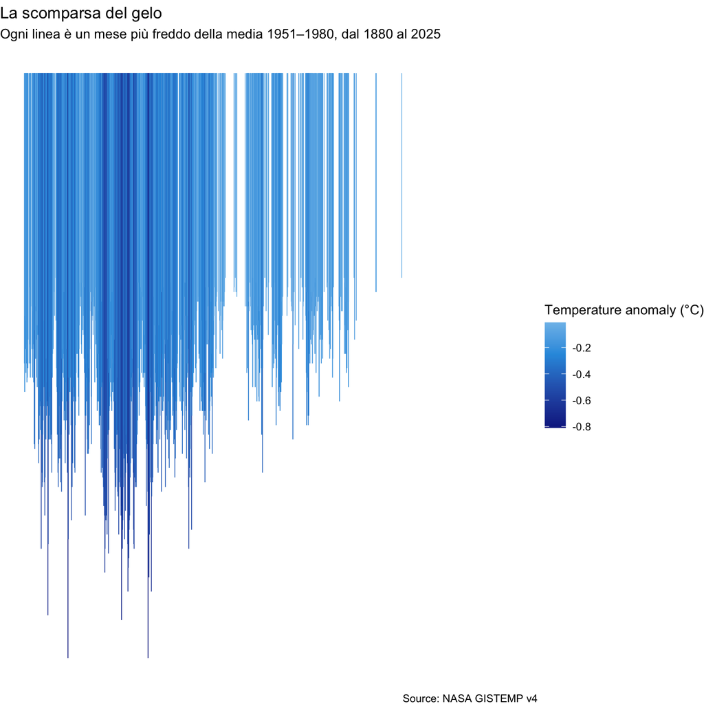

```r
art <- ggplot(cold) +
  geom_segment(
    aes(x = time, xend = time, y = 1, yend = 1 - length, color = anomaly),
    linewidth = 0.3
  ) +
  scale_color_gradient2(
    low = "#10268F",
    mid = "#2D9BE0",
    high = "#C4F1F9",
    midpoint = -0.25
  ) +
  xlim(1880, 2026) +
  labs(
    title = "La scomparsa del gelo",
    subtitle = expression(
      "Ogni linea è un mese più freddo della media 1951–1980, dal 1880 al 2025"
    ),
    color = "Temperature anomaly (°C)",
    caption = "Source: NASA GISTEMP v4"
  ) +
  theme_void()

art
```

Ogni linea (stalattite) rappresenta un mese con anomalia negativa rispetto alla media 1951–1980. La posizione orizzontale è il tempo, ho considerato da gennaio 1880 a dicembre 2025. La lunghezza delle singole stalattiti è la freddezza, cioè quanto il mese è sotto la norma, di conseguenza, più la linea è lunga, più il mese era freddo. Il colore codifica la stessa variabile, l’anomalia, ed ho scelto una palette che va dall’oltremare dei mesi più freddi al ciano di quelli appena sotto la norma. I mesi con anomalia pari o superiore a zero non vengono disegnati, poiché sono l’assenza che l’opera vuole mostrare. L’ultimo mese freddo è settembre 1992 e da ottobre 1992 al 2025 sono passati 399 mesi consecutivi senza nessuna linea.

```r
ggsave("DataArt.png", art, width = 8, height = 8, dpi = 300, bg = "white")
```